# BRIDGE screening and enrollment report

Liping Du, Dan Ayers Department of Biostatistics Vanderbilt University School of Medicine

September 22, 2022 14:36

```
unique_ids in Follow up but not in Screening dataset:
```

```
[1] "PHC---155-89-2020-11-28 08:15"
```

```
There are 13576 unique mother forms in screening dataset.
```

```
There are 41625 kids in screening dataset.
```

```
Frequency table of screening consent completion by completion of mother form:
```

```
                   mother_consent_complete
scrConsent_complete   yes
                Yes 13576
```

```
13576 mothers have completed Mother FORM with completed CONSENT for screening.
```

```
These mothers have total 41625 related kids.
```

```
                                         screen_positive
epilepsy_screening_questionnaire_complete     0     1
                                      yes 39771  1854
```

```
Total 41625  kids completed screening form 39771 screened negative, 1854 screened positive, and 0 no results(missing screen_positive)
```

```
Among those completed screening form, the frequency table of screen_positive by assigned unique_id  or not
```

```
screen_positive assigned not-assigned
            no         0        39771
            yes     1791           63
```

```
Among the 1854 screened positive kids, 1791 unique_ids were assigned.
```

```
There are total 1792 unique kids in follow up dataset.
```

```
But  1791 matched to those in screening dataset.
```

```
1791 matched to valid screened positive kids' unique_id;  0 matched to valid screened negative kids' unique_id;  0 matched to other.
```

# 1 Notes for data from screening to enrollment:

## 1.1 The process

The screening and enrollment is a 2-step consenting process with the diagnosis step in between. The process can occur either all at once or split between screening and a later follow-up time.

1. The mother consents for her child to be screened and the child is screened by the Community Health Worker (CHW). If the child screens positive at this stage the child receives a unique id. Some children may go directly to physical exam without a unique id.
2. During the above screening, age eligibility is checked. Then during further physical exam, a diagnosis by the CHW is confirmed. And if the patient is eligible (no anti-epileptic drugs in the last 3 months), second consent by the mother to enroll is needed. The physical exam and/or consent for enrollment steps can take place at the time of the screening (data captured in **screening project**) or at a later follow-up time (data captured in **follow up project**).

Two data sets (projects) contain the screening and enrollment information. All the screening and unique IDs are created in the **screening project**. The data associated with the diagnosis and enrollment steps can be in either the **screening project** or the **follow-up project** depending on when they take place.

Notes:

• light blue box: Screening project

• light gray box: Follow up project

[interactive chart not shown]

## 1.2 How the valid enrollments were identified from the screening and follow up projects?

1. From screening dataset: only those(mother/kids) completed screening consent AND completed the mother form (scrConsent_complete=1 & mother_consent_complete=2) are considered.

   Sites screening included phc=NA! if there is phc=NA.
2. Not all consented kids were screened. Count those with epilepsy_screening_questionnaire_complete=2 AND non-missing screen_positive as completed screening.
3. Then screened positive kids are those who completed screening (epilepsy_screening_questionnaire_complete=2) AND screen_positive=1.

   Note that not all screened positive kids have been assigned an unique_id. And a few kids may be assigned same unique_id!
4. Then kids who completed physical examination are those with **non-missing diagepi** (diagnosed epilepsy or not) with or without unique_id.

   Some such kids are from screening dataset and some from follow up datasets. If from follow up datasets, the kid’s unique_id should be in 3).

   Note a few kids’ data may appear in both screening and follow up datasets and they are count once.
5. The total diagnosed kids are among those in 4) with diagepi==1. Some such kids are from screening dataset and some from follow up datasets.

   Note some kids’ data may appear in both screening and follow up datasets and these kids were count once.
6. The total number of enrolled are among those who had a enrollment date (dateconsentenroll) among 3).

   Note some kids’ data may appear in both screening and follow up datasets (may or may may not be the same kid) and these kids were count once.

# 2 Diagram of data flow 1, from **screening** to **unique_id** in **screening project**.

lightblue box: normal process,or corrected data flow to screening positive patients

[interactive chart not shown]

# 3 Diagram of data flow 2, **diagnosis and enrollment** in **screening project** among screened **positive** patients.

lightblue box: normal process or data flow from diagnosis to enrollment

red box: Wrong enrollments

[interactive chart not shown]

# 4 Diagram of data flow 3, **diagnosis and enrollment** in **follow up projects**.

lightblue box: normal process or data flow to enrollment

red box: Wrong enrollments

[interactive chart not shown]

# 5 SNAPSHOT

| **Sites Screening:** | 60 |  |
| --- | --- | --- |
| **Consent for screening** | 41625 |  |
| **Total completed screening :** | 41625 |  |
| **Total screened positive:** | 1854 | 4.5 % of completed screening |
| **Total assigned unique_id:** | 1791 (1791 unique) | 96.6 % of screened positive |
| **Total completed physical examination (diagnosis):** | 1835 | 99 % of screened positive |
| - | 1245 | from screening dataset |
| - | 590 | from follow up datasets, 0 also in screening dataset |
| **Total Diagnosed Epilepsy:** | 1834 | 99.9 % of physically examined |
| - | 1244 | from screening dataset |
| - | 590 | from follow up datasets, 0 also in screening dataset |
| **Total Enrolled:** | 1771 | 96.6 % of diagnosed, including non-valid enrollments. |
| - | 1162 | from screening dataset |
| - | 609 | from follow up datasets, 0 also in screening dataset |

# 6 Off study data

## 6.1 All data

Rows highlighted with yellow are patients not enrolled.

```
enrolled
   0    1
  21 1049
```

| record_id | date_term | tracking | reason | reason_other | final_form_complete | scr_id | study_arm | city | enrolled |
| --- | --- | --- | --- | --- | --- | --- | --- | --- | --- |
| PHC---131-39-2020-06-28 16:41 | 2022-07-20 | Completed all follow-up visits | Completion of study |  | 2 | 841_1 | TSC | Zaria | 1 |
| PHC---131-39-2020-07-10 10:26 | 2022-07-26 | Completed all follow-up visits | Completion of study |  | 2 | 2844_1 | TSC | Zaria | 1 |
| PHC---131-39-2020-08-09 06:58 | 2020-10-26 | Enrolled but no follow-up visits | Participant withdrew consent |  | 2 | 6087_1 | TSC | Zaria | 1 |
| PHC---131-39-2020-08-31 11:21 | 2022-08-02 | Completed all follow-up visits | Completion of study |  | 2 | 8060_1 | TSC | Zaria | 1 |
| PHC---131-39-2020-08-31 12:02 | 2022-08-02 | Completed all follow-up visits | Completion of study |  | 2 | 8060_2 | TSC | Zaria | 1 |
| PHC---131-39-2020-12-09 12:21 | 2021-03-05 | Enrolled with some follow-up visits | Participant withdrew consent |  | 2 | 14322_1 | TSC | Zaria | 1 |
| PHC---131-72-2020-06-26 14:09 | 2020-11-04 | Failed to enroll | Participant withdrew consent |  | 2 |  |  |  | 0 |
| PHC---131-72-2020-06-29 10:09 | 2022-06-21 | Completed all follow-up visits | Completion of study |  | 2 | 904_1 | TSC | Zaria | 1 |
| PHC---131-72-2020-06-29 11:01 | 2022-06-21 | Completed all follow-up visits | Completion of study |  | 2 | 905_1 | TSC | Zaria | 1 |
| PHC---131-72-2020-07-10 10:48 | 2022-06-21 | Completed all follow-up visits | Completion of study |  | 2 | 2751_1 | TSC | Zaria | 1 |

[output cut: 1060 more lines]

## 6.2 Off study reasons and count: by city.

All

| reason | n.Kano | n.Zaria | n.Kaduna | n.total |
| --- | --- | --- | --- | --- |
| Completion of study | 450 | 265 | 73 | 788 |
| Death | 44 | 32 | 22 | 98 |
| Lost contact | 2 | 2 | 14 | 18 |
| Other | 2 | 1 | 2 | 5 |
| Participant withdrew consent | 32 | 11 | 9 | 52 |
| PI determined continuation not appropriate | 17 | 26 | 45 | 88 |

# 7 CONSORT Diagram

[interactive chart not shown]

# 8 SUMMARY

## 8.1 Summary by PHC

Notes:

Using the enrollment date in the screening dataset/project for those with duplicated enrollment date in follow up dataset, if the enrollment has a duplicate.

Only valid enrollments were count for the number of enrolled.

Yellow = PHC with number of enrolled 14 or less

Green = PHC with number of enrolled 15-24

Purple = PHC with number of enrolled 25-29

Red = PHC with number of enrolled 30 or more

|  | arm | city | phc | n.weeks screening | n.screened | n.screened/wk | n.screened positive(% screened) | n.examed.scr | n.examed.folw | n.examed.total | n.diagnosed.scr | n.diagnosed.folw | n.dignoased.total (% screened positive) | n.enrolled.scr | n.enrolled.folw | n.enrolled.total(% diagnosed |
| --- | --- | --- | --- | --- | --- | --- | --- | --- | --- | --- | --- | --- | --- | --- | --- | --- |
| 38 | TSC | Kaduna | Zakari Isa | 117.0 | 775 | 6.6 | 29 ( 3.7 % ) | 19 | 10 | 29 | 19 | 10 | 29 ( 100 % ) | 19 | 10 | 29 ( 100 % ) |
| 37 | TSC | Kaduna | Unguwar Dosa | 117.3 | 675 | 5.8 | 30 ( 4.4 % ) | 13 | 17 | 30 | 13 | 17 | 30 ( 100 % ) | 13 | 17 | 30 ( 100 % ) |
| 35 | TSC | Kaduna | Makera | 117.0 | 918 | 7.8 | 29 ( 3.2 % ) | 26 | 2 | 28 | 26 | 2 | 28 ( 96.6 % ) | 26 | 2 | 28 ( 100 % ) |
| 31 | TSC | Kaduna | Angwan Sanusi | 117.3 | 999 | 8.5 | 30 ( 3 % ) | 28 | 2 | 30 | 28 | 2 | 30 ( 100 % ) | 28 | 2 | 30 ( 100 % ) |
| 34 | TSC | Kaduna | Kabala West | 117.2 | 592 | 5.1 | 29 ( 4.9 % ) | 22 | 6 | 28 | 22 | 6 | 28 ( 96.6 % ) | 22 | 6 | 28 ( 100 % ) |
| 33 | TSC | Kaduna | Gwada | 116.5 | 946 | 8.1 | 29 ( 3.1 % ) | 13 | 16 | 29 | 13 | 16 | 29 ( 100 % ) | 13 | 16 | 29 ( 100 % ) |
| 32 | TSC | Kaduna | Farakwai | 115.3 | 714 | 6.2 | 30 ( 4.2 % ) | 27 | 2 | 29 | 27 | 2 | 29 ( 96.7 % ) | 27 | 2 | 29 ( 100 % ) |
| 36 | TSC | Kaduna | Maraban Rido | 117.2 | 1316 | 11.2 | 29 ( 2.2 % ) | 17 | 11 | 28 | 17 | 11 | 28 ( 96.6 % ) | 17 | 11 | 28 ( 100 % ) |
| 39 | TSC | Kano | Bakin Ruwa | 118.5 | 462 | 3.9 | 33 ( 7.1 % ) | 12 | 19 | 31 | 12 | 19 | 31 ( 93.9 % ) | 8 | 20 | 28 ( 90.3 % ) |
| 46 | TSC | Kano | Kuma | 118.2 | 802 | 6.8 | 29 ( 3.6 % ) | 15 | 14 | 29 | 15 | 14 | 29 ( 100 % ) | 15 | 14 | 29 ( 100 % ) |
| 51 | TSC | Kano | Sabo Garba | 117.5 | 976 | 8.3 | 30 ( 3.1 % ) | 10 | 20 | 30 | 10 | 20 | 30 ( 100 % ) | 9 | 20 | 29 ( 96.7 % ) |
| 44 | TSC | Kano | Jaba | 117.2 | 871 | 7.4 | 31 ( 3.6 % ) | 12 | 19 | 31 | 12 | 19 | 31 ( 100 % ) | 11 | 19 | 30 ( 96.8 % ) |
| 42 | TSC | Kano | Gwagwarwa | 117.5 | 646 | 5.5 | 31 ( 4.8 % ) | 23 | 7 | 30 | 23 | 7 | 30 ( 96.8 % ) | 22 | 7 | 29 ( 96.7 % ) |
| 53 | TSC | Kano | Tudun Murtala | 118.5 | 597 | 5.0 | 29 ( 4.9 % ) | 14 | 15 | 29 | 14 | 15 | 29 ( 100 % ) | 14 | 15 | 29 ( 100 % ) |
| 41 | TSC | Kano | Guringawa | 118.5 | 370 | 3.1 | 30 ( 8.1 % ) | 11 | 19 | 30 | 11 | 19 | 30 ( 100 % ) | 11 | 19 | 30 ( 100 % ) |
| 48 | TSC | Kano | Mariri | 117.5 | 945 | 8.0 | 30 ( 3.2 % ) | 25 | 5 | 30 | 25 | 5 | 30 ( 100 % ) | 23 | 6 | 29 ( 96.7 % ) |
| 40 | TSC | Kano | Gandun Albasa | 118.0 | 568 | 4.8 | 28 ( 4.9 % ) | 27 | 1 | 28 | 27 | 1 | 28 ( 100 % ) | 27 | 1 | 28 ( 100 % ) |
| 50 | TSC | Kano | Sabo Bakin Zuwo | 117.5 | 787 | 6.7 | 33 ( 4.2 % ) | 33 | 0 | 33 | 33 | 0 | 33 ( 100 % ) | 29 | 0 | 29 ( 87.9 % ) |
| 45 | TSC | Kano | Jaen | 117.5 | 819 | 7.0 | 33 ( 4 % ) | 23 | 9 | 32 | 23 | 9 | 32 ( 97 % ) | 21 | 9 | 30 ( 93.8 % ) |
| 47 | TSC | Kano | Kwamitin Makota | 118.5 | 564 | 4.8 | 31 ( 5.5 % ) | 26 | 5 | 31 | 26 | 5 | 31 ( 100 % ) | 24 | 5 | 29 ( 93.5 % ) |
| 49 | TSC | Kano | Mariya Sunusi | 118.2 | 188 | 1.6 | 34 ( 18.1 % ) | 6 | 28 | 34 | 6 | 28 | 34 ( 100 % ) | 6 | 28 | 34 ( 100 % ) |
| 52 | TSC | Kano | Tarda | 117.2 | 880 | 7.5 | 33 ( 3.8 % ) | 13 | 20 | 33 | 13 | 20 | 33 ( 100 % ) | 12 | 18 | 30 ( 90.9 % ) |
| 43 | TSC | Kano | Hausawa | 118.5 | 931 | 7.9 | 33 ( 3.5 % ) | 16 | 14 | 30 | 15 | 14 | 29 ( 87.9 % ) | 12 | 14 | 26 ( 89.7 % ) |
| 58 | TSC | Zaria | Gangara | 116.9 | 149 | 1.3 | 28 ( 18.8 % ) | 27 | 0 | 27 | 27 | 0 | 27 ( 96.4 % ) | 21 | 6 | 27 ( 100 % ) |
| 59 | TSC | Zaria | Giwa | 116.9 | 356 | 3.0 | 27 ( 7.6 % ) | 27 | 0 | 27 | 27 | 0 | 27 ( 100 % ) | 27 | 0 | 27 ( 100 % ) |
| 55 | TSC | Zaria | Basawa | 117.0 | 888 | 7.6 | 32 ( 3.6 % ) | 28 | 4 | 32 | 28 | 4 | 32 ( 100 % ) | 28 | 3 | 31 ( 96.9 % ) |
| 60 | TSC | Zaria | Shika Dam | 116.9 | 639 | 5.5 | 29 ( 4.5 % ) | 28 | 1 | 29 | 28 | 1 | 29 ( 100 % ) | 28 | 1 | 29 ( 100 % ) |
| 56 | TSC | Zaria | Dambo | 117.2 | 746 | 6.4 | 35 ( 4.7 % ) | 20 | 15 | 35 | 20 | 15 | 35 ( 100 % ) | 19 | 15 | 34 ( 97.1 % ) |
| 57 | TSC | Zaria | Dutsen Abba | 117.0 | 667 | 5.7 | 28 ( 4.2 % ) | 27 | 1 | 28 | 27 | 1 | 28 ( 100 % ) | 27 | 1 | 28 ( 100 % ) |
| 54 | TSC | Zaria | Angwan Bishar | 117.0 | 306 | 2.6 | 38 ( 12.4 % ) | 29 | 9 | 38 | 29 | 9 | 38 ( 100 % ) | 28 | 10 | 38 ( 100 % ) |
| 3 | EUC | Kaduna | Kabala | 117.3 | 401 | 3.4 | 41 ( 10.2 % ) | 7 | 33 | 40 | 7 | 33 | 40 ( 97.6 % ) | 7 | 33 | 40 ( 100 % ) |
| 1 | EUC | Kaduna | Barnawa | 118.5 | 883 | 7.5 | 31 ( 3.5 % ) | 10 | 18 | 28 | 10 | 18 | 28 ( 90.3 % ) | 10 | 18 | 28 ( 100 % ) |
| 5 | EUC | Kaduna | Kubau Road | 114.2 | 476 | 4.2 | 28 ( 5.9 % ) | 23 | 5 | 28 | 23 | 5 | 28 ( 100 % ) | 23 | 5 | 28 ( 100 % ) |
| 4 | EUC | Kaduna | Kamfani Zango | 117.5 | 755 | 6.4 | 28 ( 3.7 % ) | 15 | 13 | 28 | 15 | 13 | 28 ( 100 % ) | 15 | 13 | 28 ( 100 % ) |
| 2 | EUC | Kaduna | Birnin Yero | 117.3 | 577 | 4.9 | 27 ( 4.7 % ) | 13 | 14 | 27 | 13 | 14 | 27 ( 100 % ) | 13 | 14 | 27 ( 100 % ) |
| 7 | EUC | Kaduna | Sabon Tasha | 116.6 | 1047 | 9.0 | 30 ( 2.9 % ) | 23 | 5 | 28 | 23 | 5 | 28 ( 93.3 % ) | 23 | 5 | 28 ( 100 % ) |
| 6 | EUC | Kaduna | Kudandan | 117.3 | 913 | 7.8 | 28 ( 3.1 % ) | 20 | 8 | 28 | 20 | 8 | 28 ( 100 % ) | 20 | 8 | 28 ( 100 % ) |
| 9 | EUC | Kano | Gwammaja | 117.5 | 454 | 3.9 | 33 ( 7.3 % ) | 6 | 27 | 33 | 6 | 27 | 33 ( 100 % ) | 1 | 27 | 28 ( 84.8 % ) |
| 11 | EUC | Kano | Hajia Umma Zaria | 118.5 | 415 | 3.5 | 29 ( 7 % ) | 11 | 18 | 29 | 11 | 18 | 29 ( 100 % ) | 11 | 18 | 29 ( 100 % ) |
| 18 | EUC | Kano | Rijiyar Lemo | 118.5 | 371 | 3.1 | 30 ( 8.1 % ) | 26 | 4 | 30 | 26 | 4 | 30 ( 100 % ) | 25 | 5 | 30 ( 100 % ) |
| 12 | EUC | Kano | Hotoro North | 117.9 | 946 | 8.0 | 30 ( 3.2 % ) | 27 | 3 | 30 | 27 | 3 | 30 ( 100 % ) | 27 | 3 | 30 ( 100 % ) |
| 15 | EUC | Kano | Kaura Goje | 117.5 | 988 | 8.4 | 32 ( 3.2 % ) | 28 | 4 | 32 | 28 | 4 | 32 ( 100 % ) | 24 | 4 | 28 ( 87.5 % ) |
| 20 | EUC | Kano | Turai Yar’adua | 117.5 | 1209 | 10.3 | 31 ( 2.6 % ) | 31 | 0 | 31 | 31 | 0 | 31 ( 100 % ) | 30 | 0 | 30 ( 96.8 % ) |
| 17 | EUC | Kano | Panshekara | 117.2 | 655 | 5.6 | 31 ( 4.7 % ) | 16 | 14 | 30 | 16 | 14 | 30 ( 96.8 % ) | 15 | 14 | 29 ( 96.7 % ) |
| 21 | EUC | Kano | Unguwar Gini | 117.5 | 1093 | 9.3 | 32 ( 2.9 % ) | 13 | 19 | 32 | 13 | 19 | 32 ( 100 % ) | 10 | 19 | 29 ( 90.6 % ) |
| 22 | EUC | Kano | Yakasai Zumunta | 118.5 | 1030 | 8.7 | 31 ( 3 % ) | 30 | 1 | 31 | 30 | 1 | 31 ( 100 % ) | 26 | 2 | 28 ( 90.3 % ) |
| 8 | EUC | Kano | Dorayi Karama | 117.5 | 369 | 3.1 | 34 ( 9.2 % ) | 31 | 3 | 34 | 31 | 3 | 34 ( 100 % ) | 28 | 3 | 31 ( 91.2 % ) |
| 10 | EUC | Kano | Gwauran Dutse | 117.5 | 596 | 5.1 | 34 ( 5.7 % ) | 25 | 9 | 34 | 25 | 9 | 34 ( 100 % ) | 18 | 11 | 29 ( 85.3 % ) |
| 14 | EUC | Kano | Kadawa | 117.5 | 567 | 4.8 | 37 ( 6.5 % ) | 25 | 12 | 37 | 25 | 12 | 37 ( 100 % ) | 17 | 15 | 32 ( 86.5 % ) |
| 19 | EUC | Kano | Rijiyar Zaki | 118.5 | 356 | 3.0 | 35 ( 9.8 % ) | 27 | 8 | 35 | 27 | 8 | 35 ( 100 % ) | 22 | 8 | 30 ( 85.7 % ) |
| 13 | EUC | Kano | Jaoji | 117.5 | 722 | 6.1 | 33 ( 4.6 % ) | 29 | 4 | 33 | 29 | 4 | 33 ( 100 % ) | 23 | 6 | 29 ( 87.9 % ) |
| 16 | EUC | Kano | Kauyen Alu | 118.5 | 90 | 0.8 | 30 ( 33.3 % ) | 28 | 2 | 30 | 28 | 2 | 30 ( 100 % ) | 27 | 3 | 30 ( 100 % ) |
| 26 | EUC | Zaria | Kaya | 117.0 | 742 | 6.3 | 29 ( 3.9 % ) | 26 | 3 | 29 | 26 | 3 | 29 ( 100 % ) | 25 | 4 | 29 ( 100 % ) |
| 28 | EUC | Zaria | Shika | 116.9 | 979 | 8.4 | 30 ( 3.1 % ) | 0 | 30 | 30 | 0 | 30 | 30 ( 100 % ) | 0 | 30 | 30 ( 100 % ) |
| 25 | EUC | Zaria | Hanwa | 117.0 | 1125 | 9.6 | 31 ( 2.8 % ) | 22 | 9 | 31 | 22 | 9 | 31 ( 100 % ) | 22 | 9 | 31 ( 100 % ) |
| 23 | EUC | Zaria | Abdukwari | 117.0 | 812 | 6.9 | 27 ( 3.3 % ) | 17 | 10 | 27 | 17 | 10 | 27 ( 100 % ) | 17 | 10 | 27 ( 100 % ) |
| 27 | EUC | Zaria | Kwata | 117.7 | 467 | 4.0 | 28 ( 6 % ) | 27 | 1 | 28 | 27 | 1 | 28 ( 100 % ) | 24 | 4 | 28 ( 100 % ) |
| 29 | EUC | Zaria | Tukur-Tukur | 118.2 | 417 | 3.5 | 34 ( 8.2 % ) | 28 | 6 | 34 | 28 | 6 | 34 ( 100 % ) | 28 | 6 | 34 ( 100 % ) |
| 30 | EUC | Zaria | Unguwan Alkali | 117.2 | 634 | 5.4 | 31 ( 4.9 % ) | 17 | 14 | 31 | 17 | 14 | 31 ( 100 % ) | 17 | 14 | 31 ( 100 % ) |
| 24 | EUC | Zaria | Badan Dodo | 116.9 | 444 | 3.8 | 29 ( 6.5 % ) | 27 | 2 | 29 | 27 | 2 | 29 ( 100 % ) | 27 | 1 | 28 ( 96.6 % ) |

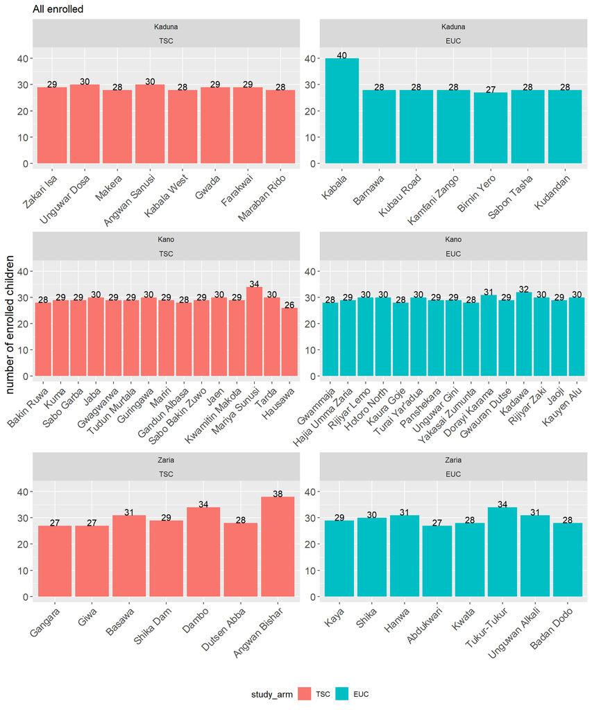

## 8.2 Summary by City

| city | n.phcs | n.screened | n.screened positive(% screened) | n.diagnosed.scr | n.diagnosed.folw | n.dignoased.total(% screened positive) | n.enrolled .scr | n.enrolled.folw | n.enrolled.total(% diagnosed) |
| --- | --- | --- | --- | --- | --- | --- | --- | --- | --- |
| Kaduna | 15 | 11987 | 448 ( 3.7 % ) | 276 | 162 | 438 ( 97.8 % ) | 276 | 162 | 438 ( 100 % ) |
| Kano | 30 | 20267 | 950 ( 4.7 % ) | 618 | 323 | 941 ( 99.1 % ) | 548 | 333 | 881 ( 93.6 % ) |
| Zaria | 15 | 9371 | 456 ( 4.9 % ) | 350 | 105 | 455 ( 99.8 % ) | 338 | 114 | 452 ( 99.3 % ) |
| Total | 60 | 41625 | 1854 ( 4.5 % ) | 1244 | 590 | 1834 ( 98.9 % ) | 1162 | 609 | 1771 ( 96.6 % ) |

## 8.3 Summary by Arm and City

| arm | city | n.phcs | n.screened | n.screened positive(% screened) | n.diagnosed.scr | n.diagnosed.folw | n.dignoased.total(% screened positive) | n.enrolled.scr | n.enrolled.folw | n.enrolled.total(% diagnosed) |
| --- | --- | --- | --- | --- | --- | --- | --- | --- | --- | --- |
| TSC | Kaduna | 8 | 6935 | 235 ( 3.4 % ) | 165 | 66 | 231 ( 98.3 % ) | 165 | 66 | 231 ( 100 % ) |
| TSC | Kano | 15 | 10406 | 468 ( 4.5 % ) | 265 | 195 | 460 ( 98.3 % ) | 244 | 195 | 439 ( 95.4 % ) |
| TSC | Zaria | 7 | 3751 | 217 ( 5.8 % ) | 186 | 30 | 216 ( 99.5 % ) | 178 | 36 | 214 ( 99.1 % ) |
| EUC | Kaduna | 7 | 5052 | 213 ( 4.2 % ) | 111 | 96 | 207 ( 97.2 % ) | 111 | 96 | 207 ( 100 % ) |
| EUC | Kano | 15 | 9861 | 482 ( 4.9 % ) | 353 | 128 | 481 ( 99.8 % ) | 304 | 138 | 442 ( 91.9 % ) |
| EUC | Zaria | 8 | 5620 | 239 ( 4.3 % ) | 164 | 75 | 239 ( 100 % ) | 160 | 78 | 238 ( 99.6 % ) |

## 8.4 Summary by Arm and City simple table

|  |  | Screened | Screened+ | Diagnosed | Enrolled |
| --- | --- | --- | --- | --- | --- |
| TSC |  | 21092 | 920 | 907 | 884 |
|  | Kaduna | 6935 | 235 | 231 | 231 |
|  | Kano | 10406 | 468 | 460 | 439 |
|  | Zaria | 3751 | 217 | 216 | 214 |
| EUC |  | 20533 | 934 | 927 | 887 |
|  | Kaduna | 5052 | 213 | 207 | 207 |
|  | Kano | 9861 | 482 | 481 | 442 |
|  | Zaria | 5620 | 239 | 239 | 238 |

## 8.5 SNAPSHOT simple table: Total and by Arm

|  | Total N | Total Difference | TSC N | EUC N |
| --- | --- | --- | --- | --- |
| Consent for screening | 41625 |  |  |  |
| Completed screening | 41625 |  | 21092 | 20533 |
| Screened positive | 1854 |  | 920 | 934 |
| Assigned unique_id | 1791<sup>c</sup> | 63<sup>a</sup> |  |  |
| Completed physical examination | 1835<sup>b</sup> | -44 |  |  |
| Diagnosed Epilepsy | 1834<sup>b</sup> | 1 | 907 | 927 |
| Enrolled (valid and unique) | 1771 | 63<sup>d</sup> | 884 | 887 |
| Off study among valid enrollments | 1049 |  | 500 | 549 |
| Current on study (valid and unique) | 722 |  | 384 | 338 |

<sup>a</sup> Not assigned,included those examined with Epilepsy but medication within 3 months  
<sup>b</sup> Not missing diagnosis result, included those not assigned unique_id  
<sup>c</sup> Included 0 duplicated unique_id  
<sup>d</sup> Included enrolled: [n = 0] not eligible due to medication within 3 months or missing medication info., missing diagnosis result [n=0] and diagnosed not-epilepsy [n=0]

# 9 SCREENING

## 9.1 Number of Children Screened by Month

### 9.1.1 By City

|  | Kaduna | Kano | Zaria | Total |
| --- | --- | --- | --- | --- |
| 2020/06 | 162 | 2765 | 1627 | 4554 |
| 2020/07 | 2447 | 5957 | 3210 | 11614 |
| 2020/08 | 3405 | 4310 | 1829 | 9544 |
| 2020/09 | 3333 | 4194 | 1488 | 9015 |
| 2020/10 | 1654 | 2008 | 753 | 4415 |
| 2020/11 | 689 | 505 | 298 | 1492 |
| 2020/12 | 136 | 163 | 90 | 389 |
| 2021/01 | 9 | 9 | 28 | 46 |
| 2021/02 | 78 | 145 | 29 | 252 |
| 2021/03 | 17 | 80 | 2 | 99 |
| 2021/04 | 5 | 15 | 2 | 22 |
| 2021/05 | 13 | 7 | 5 | 25 |
| 2021/06 | 14 | 70 | 10 | 94 |
| 2021/07 | 1 | 1 |  | 2 |
| 2021/08 | 24 | 38 |  | 62 |
| Total | 11987 | 20267 | 9371 | 41625 |

### 9.1.2 By PHC in Kaduna

|  | NA | Zakari Isa | Kabala | Unguwar Dosa | Barnawa | Makera | Angwan Sanusi | Kubau Road | Kabala West | Gwada | Farakwai | Kamfani Zango | Birnin Yero | Maraban Rido | Sabon Tasha | Kudandan | Total |
| --- | --- | --- | --- | --- | --- | --- | --- | --- | --- | --- | --- | --- | --- | --- | --- | --- | --- |
| 2020/06 |  | 4 | 12 | 9 | 11 | 32 | 10 |  | 8 | 5 |  | 39 | 2 | 2 | 4 | 24 | 162 |
| 2020/07 |  | 231 | 73 | 157 | 283 | 205 | 182 | 1 | 79 | 160 | 117 | 168 | 104 | 172 | 401 | 114 | 2447 |
| 2020/08 |  | 220 | 217 | 174 | 233 | 242 | 189 | 130 | 195 | 307 | 261 | 225 | 140 | 292 | 331 | 249 | 3405 |
| 2020/09 |  | 137 | 97 | 148 | 191 | 252 | 333 | 225 | 157 | 326 | 195 | 207 | 193 | 470 | 154 | 248 | 3333 |
| 2020/10 |  | 131 | 2 | 110 | 113 | 83 | 188 | 66 | 55 | 122 |  | 108 | 121 | 263 | 89 | 203 | 1654 |
| 2020/11 |  | 30 |  | 66 | 38 | 79 | 93 | 35 | 86 | 10 | 78 |  | 2 | 53 | 49 | 70 | 689 |
| 2020/12 |  | 17 |  |  | 8 | 9 | 1 | 5 | 4 | 7 | 28 | 6 | 9 | 23 | 19 |  | 136 |
| 2021/01 |  |  |  |  |  | 7 |  |  |  | 1 |  |  |  | 1 |  |  | 9 |
| 2021/02 |  | 4 |  | 3 | 4 | 7 |  | 7 | 3 | 2 | 16 | 1 | 2 | 29 |  |  | 78 |
| 2021/03 |  |  |  |  |  |  |  | 2 | 2 | 1 | 7 |  |  | 5 |  |  | 17 |

[output cut: 6 more lines]

### 9.1.3 By PHC in Kano

|  | NA | Bakin Ruwa | Gwammaja | Hajia Umma Zaria | Kuma | Sabo Garba | Rijiyar Lemo | Jaba | Gwagwarwa | Hotoro North | Kaura Goje | Tudun Murtala | Guringawa | Turai Yar'adua | Mariri | Panshekara | Gandun Albasa | Unguwar Gini | Sabo Bakin Zuwo | Yakasai Zumunta | Dorayi Karama | Jaen | Gwauran Dutse | Kwamitin Makota | Mariya Sunusi | Kadawa | Tarda | Rijiyar Zaki | Jaoji | … |
| --- | --- | --- | --- | --- | --- | --- | --- | --- | --- | --- | --- | --- | --- | --- | --- | --- | --- | --- | --- | --- | --- | --- | --- | --- | --- | --- | --- | --- | --- | --- |
| 2020/06 |  | 91 | 150 | 70 | 163 | 124 | 81 | 57 | 79 | 87 | 146 | 105 | 48 | 97 | 147 | 80 | 33 | 117 | 86 | 145 | 100 | 97 | 87 | 78 | 76 | 79 | 80 | 58 | 78 | … |
| 2020/07 |  | 48 | 240 | 125 | 265 | 193 | 48 | 322 | 181 | 307 | 254 | 100 | 101 | 337 | 286 | 199 | 215 | 219 | 177 | 296 | 129 | 237 | 207 | 143 | 61 | 294 | 264 | 188 | 251 | … |
| 2020/08 |  | 116 | 54 | 81 | 95 | 110 | 45 | 201 | 147 | 196 | 321 | 148 | 60 | 265 | 192 | 146 | 86 | 271 | 181 | 265 | 98 | 197 | 180 | 125 | 13 | 124 | 126 | 51 | 172 | … |
| 2020/09 |  | 89 | 6 | 66 | 119 | 239 | 128 | 169 | 103 | 278 | 144 | 114 | 123 | 289 | 193 | 162 | 133 | 266 | 223 | 191 | 29 | 260 | 75 | 72 | 4 | 70 | 231 | 23 | 118 | … |
| 2020/10 |  | 43 |  | 16 | 3 | 196 | 57 | 68 | 94 | 75 | 112 | 97 | 27 | 121 | 100 | 63 | 60 | 144 | 101 | 120 | 12 | 21 | 40 | 86 | 34 |  | 179 | 15 | 46 | … |
| 2020/11 |  | 34 | 1 | 28 | 50 | 84 | 5 | 40 | 35 |  | 6 | 15 |  | 31 | 12 |  | 27 | 68 | 12 | 5 | 1 | 6 |  | 7 |  |  |  | 6 | 20 | … |
| 2020/12 |  | 34 |  | 16 | 25 | 9 | 3 |  | 3 |  |  |  |  | 40 |  |  | 10 | 2 |  | 1 |  |  |  | 18 |  |  |  | 1 |  | … |
| 2021/01 |  |  |  |  |  | 9 |  |  |  |  |  |  |  |  |  |  |  |  |  |  |  |  |  |  |  |  |  |  |  | … |
| 2021/02 |  | 1 | 1 | 10 | 39 | 4 |  |  | 1 |  | 3 | 2 |  | 21 | 7 |  |  | 1 |  | 1 |  | 1 |  | 29 |  |  |  |  | 23 | … |
| 2021/03 |  |  |  | 2 | 36 |  |  | 5 |  |  |  |  | 1 | 6 |  |  | 2 | 2 | 2 |  |  |  | 6 | 2 |  |  |  | 10 | 6 | … |

[output cut: 6 more lines]

### 9.1.4 By PHC in Zaria

|  | NA | Gangara | Giwa | Kaya | Shika | Basawa | Hanwa | Abdukwari | Kwata | Shika Dam | Dambo | Tukur-Tukur | Dutsen Abba | Unguwan Alkali | Badan Dodo | Angwan Bishar | Total |
| --- | --- | --- | --- | --- | --- | --- | --- | --- | --- | --- | --- | --- | --- | --- | --- | --- | --- |
| 2020/06 |  | 26 | 98 | 75 | 226 | 235 | 138 | 47 | 55 | 60 | 108 | 51 | 145 | 306 | 17 | 40 | 1627 |
| 2020/07 |  | 52 | 167 | 341 | 280 | 262 | 328 | 314 | 149 | 213 | 396 | 188 | 277 | 137 | 63 | 43 | 3210 |
| 2020/08 |  | 27 | 38 | 142 | 149 | 193 | 269 | 155 | 110 | 153 | 106 | 94 | 141 | 34 | 113 | 105 | 1829 |
| 2020/09 |  | 23 | 17 | 127 | 137 | 130 | 228 | 187 | 64 | 103 | 136 | 42 | 94 | 77 | 78 | 45 | 1488 |
| 2020/10 |  | 5 | 14 | 11 | 98 | 49 | 111 | 68 | 55 | 79 |  | 42 | 10 | 80 | 62 | 69 | 753 |
| 2020/11 |  | 9 | 13 | 4 | 46 | 19 | 49 | 41 | 21 | 26 |  |  |  |  | 66 | 4 | 298 |
| 2020/12 |  | 6 | 7 | 13 | 40 |  | 2 |  | 3 | 3 |  |  |  |  | 16 |  | 90 |
| 2021/01 |  |  | 2 | 14 |  |  |  |  |  | 1 |  |  |  |  | 11 |  | 28 |
| 2021/02 |  |  |  | 15 |  |  |  |  |  | 1 |  |  |  |  | 13 |  | 29 |
| 2021/03 |  | 1 |  |  |  |  |  |  |  |  |  |  |  |  | 1 |  | 2 |

[output cut: 4 more lines]

## 9.2 Number of Children Screened by Month Plot

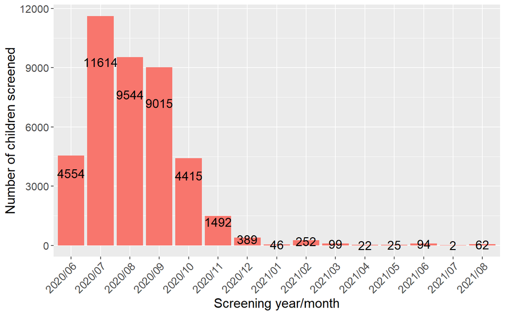

## 9.3 Children with screening dates before 06/01/2020 or after tomorrow

## 9.4 Number of Children Screened by CHW

|  | study arm | city | phc | chw id | n.screened | n.weeks screening | n.screened/wk | n.screened positive |
| --- | --- | --- | --- | --- | --- | --- | --- | --- |
| 1 | TSC | Kaduna | Zakari Isa | 37 | 238 | 116.2 | 2 | 14 |
| 2 | TSC | Kaduna | Zakari Isa | 93 | 537 | 117 | 4.6 | 15 |
| 3 | TSC | Kaduna | Unguwar Dosa | 8 | 203 | 116.5 | 1.7 | 14 |
| 4 | TSC | Kaduna | Unguwar Dosa | 24 | 472 | 117.3 | 4 | 16 |
| 5 | TSC | Kaduna | Makera | 30 | 517 | 117 | 4.4 | 16 |
| 6 | TSC | Kaduna | Makera | 47 | 401 | 117 | 3.4 | 13 |
| 7 | TSC | Kaduna | Angwan Sanusi | 69 | 497 | 117.3 | 4.2 | 17 |
| 8 | TSC | Kaduna | Angwan Sanusi | 77 | 502 | 116.9 | 4.3 | 13 |
| 9 | TSC | Kaduna | Kabala West | 40 | 394 | 117.2 | 3.4 | 16 |
| 10 | TSC | Kaduna | Kabala West | 73 | 195 | 117.2 | 1.7 | 13 |

[output cut: 119 more lines]

# 10 ENROLLMENT (Only those valid, using the earliest enrollment date for those with multiple enrollment dates )

## 10.1 Number of Children Enrolled by Month

### 10.1.1 By City

```
All:
```

|  | Kaduna | Kano | Zaria | Total |
| --- | --- | --- | --- | --- |
| 2020/06 | 11 | 58 | 22 | 91 |
| 2020/07 | 29 | 120 | 101 | 250 |
| 2020/08 | 52 | 114 | 93 | 259 |
| 2020/09 | 44 | 177 | 103 | 324 |
| 2020/10 | 45 | 132 | 36 | 213 |
| 2020/11 | 88 | 86 | 50 | 224 |
| 2020/12 | 84 | 42 | 23 | 149 |
| 2021/01 | 5 |  | 8 | 13 |
| 2021/02 | 34 | 37 | 8 | 79 |
| 2021/03 | 12 | 29 | 2 | 43 |
| 2021/04 | 1 | 15 | 1 | 17 |
| 2021/05 | 10 | 7 | 1 | 18 |
| 2021/06 | 7 | 37 | 4 | 48 |
| 2021/07 | 1 | 4 |  | 5 |
| 2021/08 | 15 | 23 |  | 38 |
| Total | 438 | 881 | 452 | 1771 |

```
TSC arm:
```

|  | Kaduna | Kano | Zaria | Total |
| --- | --- | --- | --- | --- |
| 2020/06 | 3 | 23 | 21 | 47 |
| 2020/07 | 19 | 57 | 39 | 115 |
| 2020/08 | 23 | 56 | 53 | 132 |
| 2020/09 | 22 | 81 | 51 | 154 |
| 2020/10 | 18 | 68 | 13 | 99 |
| 2020/11 | 47 | 50 | 21 | 118 |
| 2020/12 | 41 | 27 | 10 | 78 |
| 2021/01 | 5 |  | 4 | 9 |
| 2021/02 | 20 | 21 | 1 | 42 |
| 2021/03 | 11 | 15 | 1 | 27 |
| 2021/04 | 1 | 6 |  | 7 |
| 2021/05 | 2 | 1 |  | 3 |
| 2021/06 | 6 | 17 |  | 23 |
| 2021/07 | 1 | 3 |  | 4 |
| 2021/08 | 12 | 14 |  | 26 |
| Total | 231 | 439 | 214 | 884 |

```
EUC arm:
```

|  | Kaduna | Kano | Zaria | Total |
| --- | --- | --- | --- | --- |
| 2020/06 | 8 | 35 | 1 | 44 |
| 2020/07 | 10 | 63 | 62 | 135 |
| 2020/08 | 29 | 58 | 40 | 127 |
| 2020/09 | 22 | 96 | 52 | 170 |
| 2020/10 | 27 | 64 | 23 | 114 |
| 2020/11 | 41 | 36 | 29 | 106 |
| 2020/12 | 43 | 15 | 13 | 71 |
| 2021/01 |  |  | 4 | 4 |
| 2021/02 | 14 | 16 | 7 | 37 |
| 2021/03 | 1 | 14 | 1 | 16 |
| 2021/04 |  | 9 | 1 | 10 |
| 2021/05 | 8 | 6 | 1 | 15 |
| 2021/06 | 1 | 20 | 4 | 25 |
| 2021/07 |  | 1 |  | 1 |
| 2021/08 | 3 | 9 |  | 12 |
| Total | 207 | 442 | 238 | 887 |

### 10.1.2 By PHC in Kaduna

|  | NA | Zakari Isa | Kabala | Unguwar Dosa | Barnawa | Makera | Angwan Sanusi | Kubau Road | Kabala West | Gwada | Farakwai | Kamfani Zango | Birnin Yero | Maraban Rido | Sabon Tasha | Kudandan | Total |
| --- | --- | --- | --- | --- | --- | --- | --- | --- | --- | --- | --- | --- | --- | --- | --- | --- | --- |
| 2020/06 |  |  | 4 |  |  |  | 3 |  |  |  |  |  | 2 |  | 1 | 1 | 11 |
| 2020/07 |  | 5 | 2 | 3 | 2 | 3 | 3 |  | 4 |  | 1 |  | 1 |  | 1 | 4 | 29 |
| 2020/08 |  | 1 | 19 | 4 | 2 |  | 3 | 1 | 3 | 7 | 4 | 5 |  | 1 | 2 |  | 52 |
| 2020/09 |  | 4 | 7 | 2 |  | 2 | 5 | 2 | 1 | 4 |  | 7 | 6 | 4 |  |  | 44 |
| 2020/10 |  |  | 8 | 7 | 3 | 4 |  | 1 | 1 | 4 |  | 11 | 3 | 2 |  | 1 | 45 |
| 2020/11 |  | 1 |  | 10 | 2 | 6 | 12 | 9 | 8 | 2 | 5 |  | 1 | 3 | 9 | 20 | 88 |
| 2020/12 |  | 13 |  |  | 13 | 4 | 1 | 5 | 3 | 4 | 9 | 3 | 8 | 7 | 14 |  | 84 |
| 2021/01 |  |  |  |  |  | 4 |  |  |  |  |  |  |  | 1 |  |  | 5 |
| 2021/02 |  | 4 |  | 1 | 4 | 3 |  | 6 | 3 | 3 | 3 | 1 | 2 | 3 | 1 |  | 34 |
| 2021/03 |  |  |  |  |  |  |  | 1 | 2 | 1 | 3 |  |  | 5 |  |  | 12 |

[output cut: 6 more lines]

### 10.1.3 By PHC in Kano

|  | NA | Bakin Ruwa | Gwammaja | Hajia Umma Zaria | Kuma | Sabo Garba | Rijiyar Lemo | Jaba | Gwagwarwa | Hotoro North | Kaura Goje | Tudun Murtala | Guringawa | Turai Yar'adua | Mariri | Panshekara | Gandun Albasa | Unguwar Gini | Sabo Bakin Zuwo | Yakasai Zumunta | Dorayi Karama | Jaen | Gwauran Dutse | Kwamitin Makota | Mariya Sunusi | Kadawa | Tarda | Rijiyar Zaki | Jaoji | … |
| --- | --- | --- | --- | --- | --- | --- | --- | --- | --- | --- | --- | --- | --- | --- | --- | --- | --- | --- | --- | --- | --- | --- | --- | --- | --- | --- | --- | --- | --- | --- |
| 2020/06 |  | 1 | 6 | 5 |  |  | 2 | 1 | 2 |  | 1 | 2 | 7 | 1 | 1 | 5 | 1 |  | 1 |  | 7 |  |  |  | 5 | 1 |  | 1 | 1 | … |
| 2020/07 |  | 9 | 6 | 5 | 2 | 1 | 4 | 3 | 2 | 5 | 2 | 3 | 2 | 3 | 1 |  |  | 3 | 2 | 1 | 11 | 3 | 5 | 4 | 19 | 2 | 4 | 2 | 5 | … |
| 2020/08 |  | 1 | 9 | 2 | 4 | 4 | 3 | 2 | 3 | 3 | 4 | 3 | 3 |  | 4 | 1 | 5 | 1 | 6 |  | 6 | 5 | 2 | 3 | 5 | 16 | 7 | 3 | 3 | … |
| 2020/09 |  | 2 | 3 | 3 | 1 | 6 | 2 | 4 | 8 | 3 | 8 | 4 | 8 | 3 | 7 | 17 | 4 | 6 | 7 | 7 | 6 | 10 | 12 | 1 | 1 | 13 | 12 | 8 | 2 | … |
| 2020/10 |  | 1 |  | 2 | 4 | 3 | 8 | 9 | 1 | 16 | 5 | 1 | 5 | 4 | 10 | 2 | 1 | 6 | 7 | 7 | 1 | 8 | 7 | 1 | 4 |  | 6 | 5 |  | … |
| 2020/11 |  | 2 | 1 | 4 | 1 | 4 | 4 | 6 | 7 |  | 5 | 8 |  | 2 | 3 |  | 3 | 5 | 2 | 5 |  | 3 |  | 4 |  |  | 1 | 3 | 6 | … |
| 2020/12 |  | 7 |  | 1 | 2 | 2 | 3 |  | 2 |  |  |  |  | 7 |  |  | 10 | 2 |  | 1 |  |  |  | 3 |  |  |  | 1 |  | … |
| 2021/02 |  | 1 |  | 3 | 5 | 4 |  |  | 1 |  | 2 | 1 |  | 6 | 1 |  |  | 1 |  | 1 |  | 1 |  | 7 |  |  |  |  | 2 | … |
| 2021/03 |  |  | 1 | 3 | 6 |  |  | 1 |  |  |  | 1 | 1 | 2 |  |  | 2 |  | 2 |  |  |  | 2 | 2 |  |  |  | 3 | 3 | … |
| 2021/04 |  | 2 | 1 |  |  | 1 | 2 |  | 2 |  |  | 1 |  | 1 |  |  |  | 2 |  | 2 |  |  |  |  |  |  |  |  | 1 | … |

[output cut: 5 more lines]

### 10.1.4 By PHC in Zaria

|  | NA | Gangara | Giwa | Kaya | Shika | Basawa | Hanwa | Abdukwari | Kwata | Shika Dam | Dambo | Tukur-Tukur | Dutsen Abba | Unguwan Alkali | Badan Dodo | Angwan Bishar | Total |
| --- | --- | --- | --- | --- | --- | --- | --- | --- | --- | --- | --- | --- | --- | --- | --- | --- | --- |
| 2020/06 |  | 3 | 8 |  |  | 1 |  |  |  | 1 | 5 |  | 1 | 1 |  | 2 | 22 |
| 2020/07 |  | 6 | 2 | 4 | 6 | 5 | 3 | 2 | 11 | 4 | 8 | 14 | 3 | 18 | 4 | 11 | 101 |
| 2020/08 |  | 7 | 4 | 8 | 4 | 3 | 4 | 5 | 1 | 5 | 8 | 9 | 18 | 5 | 4 | 8 | 93 |
| 2020/09 |  | 3 | 4 | 5 | 4 | 12 | 14 | 12 | 5 | 3 | 13 | 6 | 4 | 4 | 2 | 12 | 103 |
| 2020/10 |  |  | 2 | 2 | 4 | 4 | 2 | 3 | 2 | 4 |  | 5 | 2 | 3 | 2 | 1 | 36 |
| 2020/11 |  | 2 | 2 |  | 4 | 6 | 7 | 5 | 5 | 7 |  |  |  |  | 8 | 4 | 50 |
| 2020/12 |  | 4 | 4 | 3 | 7 |  | 1 |  | 1 | 2 |  |  |  |  | 1 |  | 23 |
| 2021/01 |  | 1 | 1 | 3 |  |  |  |  |  | 2 |  |  |  |  | 1 |  | 8 |
| 2021/02 |  |  |  | 4 |  |  |  |  |  | 1 |  |  |  |  | 3 |  | 8 |
| 2021/03 |  | 1 |  |  |  |  |  |  |  |  |  |  |  |  | 1 |  | 2 |

[output cut: 4 more lines]

## 10.2 Number of Children Enrolled: observed and expected plot

```
red date=predicted date reaching 1800, blue dates= 95% confidence interval of predicted date reaching 1800
```

```
Predictions based on observed enrollment rate from the most recent 30 days
```

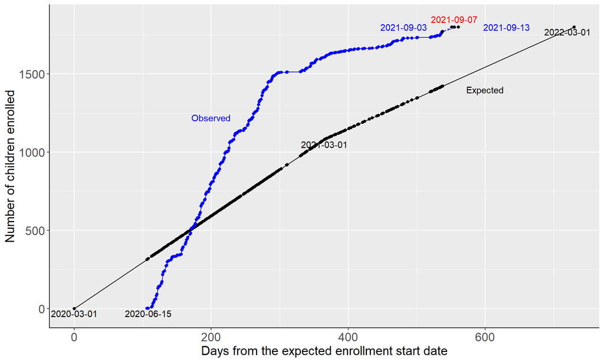

# 11 Demographics of Mother/Guardian who completed screening form by City

| Descriptive Statistics *(N=13576)*. | Descriptive Statistics *(N=13576)*. N | Descriptive Statistics *(N=13576)*. Kaduna *N=4310* | Descriptive Statistics *(N=13576)*. Kano *N=5927* | Descriptive Statistics *(N=13576)*. Zaria *N=3339* | Descriptive Statistics *(N=13576)*. Combined *N=13576* |
| --- | --- | --- | --- | --- | --- |
| loc_scr | 13575 |  |  |  |  |
| Clinic(PHC) |  | 57% (2474) | 7% ( 412) | 40% (1325) | 31% (4211) |
| Community |  | 43% (1832) | 93% (5513) | 60% (2006) | 69% (9351) |
| School |  | 0% ( 4) | 0% ( 2) | 0% ( 7) | 0% ( 13) |
| gender_p | 13321 |  |  |  |  |
| Female |  | 98% ( 4201) | 98% ( 5651) | 98% ( 3244) | 98% (13096) |
| Male |  | 2% ( 65) | 2% ( 108) | 2% ( 52) | 2% ( 225) |
| Guardian's age | 13570 | 27.00 31.00 36.70 (32.22 ± 7.60) | 28.00 33.30 40.00 (34.33 ± 8.72) | 25.00 30.00 35.40 (30.89 ± 8.58) | 26.40 31.30 38.00 (32.82 ± 8.47) |
| educ_p | 13561 |  |  |  |  |
| No formal education |  | 20% ( 853) | 24% (1420) | 32% (1060) | 25% (3333) |
| Primary School |  | 15% ( 659) | 18% (1071) | 26% ( 853) | 19% (2583) |
| Junior Secondary School |  | 12% ( 499) | 12% ( 708) | 13% ( 439) | 12% (1646) |
| Senior Secondary School |  | 31% (1344) | 31% (1837) | 21% ( 693) | 29% (3874) |
| Technical College |  | 6% ( 275) | 3% ( 206) | 1% ( 49) | 4% ( 530) |
| College |  | 10% ( 429) | 9% ( 511) | 5% ( 167) | 8% (1107) |
| University |  | 5% ( 227) | 3% ( 157) | 2% ( 67) | 3% ( 451) |
| Master Degree |  | 0% ( 16) | 0% ( 7) | 0% ( 8) | 0% ( 31) |
| Doctorate Degree |  | 0% ( 6) | 0% ( 0) | 0% ( 0) | 0% ( 6) |
| reled_p | 13474 |  |  |  |  |
| No |  | 1% ( 32) | 1% ( 45) | 5% ( 162) | 2% ( 239) |
| Yes |  | 99% ( 4228) | 99% ( 5858) | 95% ( 3149) | 98% (13235) |
| marital_status | 13566 |  |  |  |  |
| Married Monogamous |  | 83% ( 3572) | 80% ( 4712) | 69% ( 2317) | 78% (10601) |
| Married Polygamous |  | 16% ( 689) | 19% ( 1099) | 29% ( 984) | 20% ( 2772) |
| Single |  | 0% ( 9) | 0% ( 15) | 0% ( 7) | 0% ( 31) |
| Divorced |  | 0% ( 8) | 1% ( 34) | 0% ( 11) | 0% ( 53) |
| Widow |  | 1% ( 29) | 1% ( 61) | 1% ( 19) | 1% ( 109) |
| ethnicity | 13558 |  |  |  |  |
| Hausa |  | 65% ( 2804) | 94% ( 5574) | 94% ( 3135) | 85% (11513) |
| Fulani |  | 4% ( 176) | 4% ( 235) | 4% ( 129) | 4% ( 540) |
| Yoruba |  | 6% ( 246) | 0% ( 28) | 1% ( 27) | 2% ( 301) |
| Igbo |  | 3% ( 114) | 0% ( 10) | 0% ( 4) | 1% ( 128) |
| Efik |  | 0% ( 4) | 0% ( 1) | 0% ( 0) | 0% ( 5) |
| Ibibio |  | 0% ( 5) | 0% ( 0) | 0% ( 0) | 0% ( 5) |
| Ijaw |  | 0% ( 2) | 0% ( 0) | 0% ( 0) | 0% ( 2) |
| Urhobo-Isoko |  | 0% ( 1) | 0% ( 0) | 0% ( 0) | 0% ( 1) |
| Edo |  | 1% ( 24) | 0% ( 4) | 0% ( 1) | 0% ( 29) |
| Itsekiri |  | 0% ( 3) | 0% ( 0) | 0% ( 0) | 0% ( 3) |
| Other |  | 22% ( 929) | 1% ( 62) | 1% ( 40) | 8% ( 1031) |
| race | 13571 |  |  |  |  |
| Other |  | 0% ( 17) | 0% ( 22) | 2% ( 70) | 1% ( 109) |
| Black African |  | 100% ( 4293) | 100% ( 5901) | 98% ( 3268) | 99% (13462) |
| primary_language | 13575 |  |  |  |  |
| Hausa |  | 68% ( 2919) | 94% ( 5557) | 94% ( 3152) | 86% (11628) |
| Yoruba |  | 5% ( 206) | 0% ( 29) | 1% ( 26) | 2% ( 261) |
| Fulfulde |  | 0% ( 2) | 0% ( 3) | 0% ( 0) | 0% ( 5) |
| Igbo |  | 2% ( 72) | 0% ( 11) | 0% ( 3) | 1% ( 86) |
| English |  | 7% ( 318) | 0% ( 6) | 0% ( 1) | 2% ( 325) |
| Other |  | 15% ( 625) | 1% ( 66) | 1% ( 38) | 5% ( 729) |
| Fulani |  | 4% ( 167) | 4% ( 255) | 4% ( 119) | 4% ( 541) |
| Number of children in household | 13563 | 2.00 3.00 4.00 (3.08 ±1.85) | 2.00 3.00 5.00 (3.49 ±1.88) | 2.00 4.00 6.00 (4.19 ±2.90) | 2.00 3.00 5.00 (3.53 ±2.21) |

*a* *b* *c* represent the lower quartile *a*, the median *b*, and the upper quartile *c* for continuous variables. *x ± s* represents X ± 1 SD. *N* is the number of non-missing values. Numbers after proportions are frequencies.

# 12 Demographics of Children who completed screening form by Arm

| Descriptive Statistics *(N=41625)*. | Descriptive Statistics *(N=41625)*. N | Descriptive Statistics *(N=41625)*. TSC *N=21092* | Descriptive Statistics *(N=41625)*. EUC *N=20533* | Descriptive Statistics *(N=41625)*. Combined *N=41625* |
| --- | --- | --- | --- | --- |
| ethnicity | 41544 |  |  |  |
| Hausa |  | 88% (18501) | 87% (17800) | 87% (36301) |
| Fulani |  | 5% ( 988) | 3% ( 697) | 4% ( 1685) |
| Yoruba |  | 2% ( 402) | 1% ( 290) | 2% ( 692) |
| Igbo |  | 0% ( 89) | 1% ( 235) | 1% ( 324) |
| Efik |  | 0% ( 6) | 0% ( 6) | 0% ( 12) |
| Ibibio |  | 0% ( 9) | 0% ( 2) | 0% ( 11) |
| Ijaw |  | 0% ( 3) | 0% ( 1) | 0% ( 4) |
| Urhobo-Isoko |  | 0% ( 2) | 0% ( 0) | 0% ( 2) |
| Edo |  | 0% ( 36) | 0% ( 32) | 0% ( 68) |
| Itsekiri |  | 0% ( 8) | 0% ( 0) | 0% ( 8) |
| Other |  | 5% ( 984) | 7% ( 1453) | 6% ( 2437) |
| race | 41610 |  |  |  |
| Other |  | 1% ( 161) | 0% ( 96) | 1% ( 257) |
| Black African |  | 99% (20927) | 100% (20426) | 99% (41353) |
| primary_language | 41621 |  |  |  |
| Hausa |  | 88% (18598) | 88% (18008) | 88% (36606) |
| Yoruba |  | 2% ( 341) | 1% ( 266) | 1% ( 607) |
| Fulfulde |  | 0% ( 20) | 0% ( 3) | 0% ( 23) |
| Igbo |  | 0% ( 70) | 1% ( 154) | 1% ( 224) |
| English |  | 2% ( 354) | 2% ( 377) | 2% ( 731) |
| Other |  | 3% ( 680) | 5% ( 1077) | 4% ( 1757) |
| Fulani |  | 5% ( 1025) | 3% ( 648) | 4% ( 1673) |
| age | 41623 | 4.00 7.20 11.30 ( 7.79 ± 4.59) | 4.00 7.20 11.10 ( 7.72 ± 4.51) | 4.00 7.20 11.20 ( 7.76 ± 4.55) |
| gender | 41622 |  |  |  |
| Female |  | 49% (10408) | 51% (10493) | 50% (20901) |
| Male |  | 51% (10669) | 49% (10026) | 50% (20695) |
| Unknown |  | 0% ( 10) | 0% ( 7) | 0% ( 17) |
| Unspecified |  | 0% ( 3) | 0% ( 6) | 0% ( 9) |
| school | 41592 |  |  |  |
| No |  | 36% ( 7586) | 36% ( 7439) | 36% (15025) |
| Yes |  | 64% (13487) | 64% (13080) | 64% (26567) |
| grade | 26483 |  |  |  |
| Primary School - Year 1 |  | 25% (3340) | 26% (3390) | 25% (6730) |
| Primary School - Year 2 |  | 14% (1927) | 14% (1882) | 14% (3809) |
| Primary School - Year 3 |  | 12% (1584) | 12% (1576) | 12% (3160) |
| Primary School - Year 4 |  | 9% (1220) | 9% (1151) | 9% (2371) |
| Primary School - Year 5 |  | 6% ( 868) | 8% ( 986) | 7% (1854) |
| Primary School - Year 6 |  | 7% ( 891) | 6% ( 778) | 6% (1669) |
| Junior Secondary School - Year 1 |  | 7% ( 951) | 7% ( 917) | 7% (1868) |
| Junior Secondary School - Year 2 |  | 6% ( 761) | 6% ( 820) | 6% (1581) |
| Junior Secondary School - Year 3 |  | 5% ( 680) | 5% ( 631) | 5% (1311) |
| Senior Secondary School - Year 1 |  | 3% ( 467) | 3% ( 405) | 3% ( 872) |
| Senior Secondary School - Year 2 |  | 3% ( 420) | 3% ( 342) | 3% ( 762) |
| Senior Secondary School - Year 3 |  | 2% ( 302) | 1% ( 194) | 2% ( 496) |
| screen_positive | 41625 |  |  |  |
| 0 |  | 96% (20172) | 95% (19599) | 96% (39771) |
| 1 |  | 4% ( 920) | 5% ( 934) | 4% ( 1854) |

*a* *b* *c* represent the lower quartile *a*, the median *b*, and the upper quartile *c* for continuous variables. *x ± s* represents X ± 1 SD. *N* is the number of non-missing values. Numbers after proportions are frequencies.

# 13 Demographics of Children Enrolled (valid and unique) by Arm

| Descriptive Statistics *(N=1771)*. | Descriptive Statistics *(N=1771)*. N | Descriptive Statistics *(N=1771)*. TSC *N=884* | Descriptive Statistics *(N=1771)*. EUC *N=887* | Descriptive Statistics *(N=1771)*. Combined *N=1771* |
| --- | --- | --- | --- | --- |
| ethnicity | 1770 |  |  |  |
| Hausa |  | 90% ( 791) | 93% ( 824) | 91% (1615) |
| Fulani |  | 6% ( 51) | 2% ( 22) | 4% ( 73) |
| Yoruba |  | 1% ( 8) | 1% ( 6) | 1% ( 14) |
| Igbo |  | 0% ( 2) | 0% ( 1) | 0% ( 3) |
| Efik |  | 0% ( 0) | 0% ( 0) | 0% ( 0) |
| Ibibio |  | 0% ( 1) | 0% ( 0) | 0% ( 1) |
| Ijaw |  | 0% ( 0) | 0% ( 0) | 0% ( 0) |
| Urhobo-Isoko |  | 0% ( 0) | 0% ( 0) | 0% ( 0) |
| Edo |  | 0% ( 0) | 0% ( 0) | 0% ( 0) |
| Itsekiri |  | 0% ( 0) | 0% ( 0) | 0% ( 0) |
| Other |  | 3% ( 30) | 4% ( 34) | 4% ( 64) |
| race | 1771 |  |  |  |
| Other |  | 0% ( 3) | 0% ( 2) | 0% ( 5) |
| Black African |  | 100% ( 881) | 100% ( 885) | 100% (1766) |
| primary_language | 1771 |  |  |  |
| Hausa |  | 90% ( 797) | 94% ( 834) | 92% (1631) |
| Yoruba |  | 1% ( 8) | 1% ( 5) | 1% ( 13) |
| Fulfulde |  | 0% ( 0) | 0% ( 0) | 0% ( 0) |
| Igbo |  | 0% ( 2) | 0% ( 1) | 0% ( 3) |
| English |  | 1% ( 5) | 1% ( 5) | 1% ( 10) |
| Other |  | 3% ( 28) | 2% ( 20) | 3% ( 48) |
| Fulani |  | 5% ( 44) | 2% ( 22) | 4% ( 66) |
| age | 1771 | 6.00 10.00 14.10 ( 9.78 ± 4.65) | 5.20 9.00 14.00 ( 9.39 ± 4.78) | 5.65 9.30 14.00 ( 9.58 ± 4.72) |
| gender | 1771 |  |  |  |
| Female |  | 36% ( 316) | 36% ( 317) | 36% ( 633) |
| Male |  | 64% ( 568) | 64% ( 570) | 64% (1138) |
| Unknown |  | 0% ( 0) | 0% ( 0) | 0% ( 0) |
| Unspecified |  | 0% ( 0) | 0% ( 0) | 0% ( 0) |
| school | 1770 |  |  |  |
| No |  | 56% ( 497) | 57% ( 505) | 57% (1002) |
| Yes |  | 44% ( 387) | 43% ( 381) | 43% ( 768) |
| grade | 773 |  |  |  |
| Primary School - Year 1 |  | 31% (121) | 27% (105) | 29% (226) |
| Primary School - Year 2 |  | 16% ( 63) | 17% ( 65) | 17% (128) |
| Primary School - Year 3 |  | 12% ( 46) | 12% ( 45) | 12% ( 91) |
| Primary School - Year 4 |  | 8% ( 32) | 8% ( 30) | 8% ( 62) |
| Primary School - Year 5 |  | 6% ( 23) | 7% ( 28) | 7% ( 51) |
| Primary School - Year 6 |  | 8% ( 32) | 8% ( 31) | 8% ( 63) |
| Junior Secondary School - Year 1 |  | 6% ( 23) | 6% ( 24) | 6% ( 47) |
| Junior Secondary School - Year 2 |  | 4% ( 14) | 4% ( 15) | 4% ( 29) |
| Junior Secondary School - Year 3 |  | 4% ( 14) | 4% ( 17) | 4% ( 31) |
| Senior Secondary School - Year 1 |  | 2% ( 9) | 3% ( 12) | 3% ( 21) |
| Senior Secondary School - Year 2 |  | 2% ( 6) | 1% ( 4) | 1% ( 10) |
| Senior Secondary School - Year 3 |  | 2% ( 7) | 2% ( 7) | 2% ( 14) |
| educ_p | 1770 |  |  |  |
| No formal education |  | 42% (369) | 37% (327) | 39% (696) |
| Primary School |  | 27% (238) | 24% (212) | 25% (450) |
| Junior Secondary School |  | 8% ( 71) | 10% ( 92) | 9% (163) |
| Senior Secondary School |  | 17% (148) | 22% (193) | 19% (341) |
| Technical College |  | 2% ( 14) | 0% ( 4) | 1% ( 18) |
| College |  | 4% ( 32) | 5% ( 42) | 4% ( 74) |
| University |  | 1% ( 8) | 2% ( 14) | 1% ( 22) |
| Master Degree |  | 0% ( 4) | 0% ( 2) | 0% ( 6) |
| Doctorate Degree |  | 0% ( 0) | 0% ( 0) | 0% ( 0) |

*a* *b* *c* represent the lower quartile *a*, the median *b*, and the upper quartile *c* for continuous variables. *x ± s* represents X ± 1 SD. *N* is the number of non-missing values. Numbers after proportions are frequencies.

# 14 Demographics of Children Enrolled (valid and unique) by City

| Descriptive Statistics *(N=1771)*. | Descriptive Statistics *(N=1771)*. N | Descriptive Statistics *(N=1771)*. Kaduna *N=438* | Descriptive Statistics *(N=1771)*. Kano *N=881* | Descriptive Statistics *(N=1771)*. Zaria *N=452* | Descriptive Statistics *(N=1771)*. Combined *N=1771* |
| --- | --- | --- | --- | --- | --- |
| ethnicity | 1770 |  |  |  |  |
| Hausa |  | 81% ( 356) | 94% ( 829) | 95% ( 430) | 91% (1615) |
| Fulani |  | 3% ( 15) | 5% ( 42) | 4% ( 16) | 4% ( 73) |
| Yoruba |  | 2% ( 8) | 0% ( 2) | 1% ( 4) | 1% ( 14) |
| Igbo |  | 1% ( 3) | 0% ( 0) | 0% ( 0) | 0% ( 3) |
| Efik |  | 0% ( 0) | 0% ( 0) | 0% ( 0) | 0% ( 0) |
| Ibibio |  | 0% ( 1) | 0% ( 0) | 0% ( 0) | 0% ( 1) |
| Ijaw |  | 0% ( 0) | 0% ( 0) | 0% ( 0) | 0% ( 0) |
| Urhobo-Isoko |  | 0% ( 0) | 0% ( 0) | 0% ( 0) | 0% ( 0) |
| Edo |  | 0% ( 0) | 0% ( 0) | 0% ( 0) | 0% ( 0) |
| Itsekiri |  | 0% ( 0) | 0% ( 0) | 0% ( 0) | 0% ( 0) |
| Other |  | 13% ( 55) | 1% ( 7) | 0% ( 2) | 4% ( 64) |
| race | 1771 |  |  |  |  |
| Other |  | 1% ( 3) | 0% ( 1) | 0% ( 1) | 0% ( 5) |
| Black African |  | 99% ( 435) | 100% ( 880) | 100% ( 451) | 100% (1766) |
| primary_language | 1771 |  |  |  |  |
| Hausa |  | 84% ( 368) | 95% ( 833) | 95% ( 430) | 92% (1631) |
| Yoruba |  | 2% ( 7) | 0% ( 2) | 1% ( 4) | 1% ( 13) |
| Fulfulde |  | 0% ( 0) | 0% ( 0) | 0% ( 0) | 0% ( 0) |
| Igbo |  | 1% ( 3) | 0% ( 0) | 0% ( 0) | 0% ( 3) |
| English |  | 2% ( 9) | 0% ( 1) | 0% ( 0) | 1% ( 10) |
| Other |  | 8% ( 37) | 1% ( 9) | 0% ( 2) | 3% ( 48) |
| Fulani |  | 3% ( 14) | 4% ( 36) | 4% ( 16) | 4% ( 66) |
| age | 1771 | 5.30 9.00 13.80 ( 9.43 ± 4.70) | 5.60 9.20 14.00 ( 9.63 ± 4.72) | 6.00 10.00 14.00 ( 9.65 ± 4.74) | 5.65 9.30 14.00 ( 9.58 ± 4.72) |
| gender | 1771 |  |  |  |  |
| Female |  | 37% ( 162) | 35% ( 309) | 36% ( 162) | 36% ( 633) |
| Male |  | 63% ( 276) | 65% ( 572) | 64% ( 290) | 64% (1138) |
| school | 1770 |  |  |  |  |
| No |  | 58% ( 256) | 55% ( 485) | 58% ( 261) | 57% (1002) |
| Yes |  | 42% ( 182) | 45% ( 395) | 42% ( 191) | 43% ( 768) |
| grade | 773 |  |  |  |  |
| Primary School - Year 1 |  | 31% ( 55) | 28% (113) | 30% ( 58) | 29% (226) |
| Primary School - Year 2 |  | 16% ( 29) | 18% ( 70) | 15% ( 29) | 17% (128) |
| Primary School - Year 3 |  | 9% ( 17) | 14% ( 54) | 10% ( 20) | 12% ( 91) |
| Primary School - Year 4 |  | 8% ( 14) | 8% ( 31) | 9% ( 17) | 8% ( 62) |
| Primary School - Year 5 |  | 6% ( 11) | 7% ( 27) | 7% ( 13) | 7% ( 51) |
| Primary School - Year 6 |  | 8% ( 14) | 7% ( 29) | 10% ( 20) | 8% ( 63) |
| Junior Secondary School - Year 1 |  | 8% ( 14) | 5% ( 21) | 6% ( 12) | 6% ( 47) |
| Junior Secondary School - Year 2 |  | 3% ( 5) | 4% ( 14) | 5% ( 10) | 4% ( 29) |
| Junior Secondary School - Year 3 |  | 3% ( 5) | 5% ( 20) | 3% ( 6) | 4% ( 31) |
| Senior Secondary School - Year 1 |  | 5% ( 9) | 3% ( 10) | 1% ( 2) | 3% ( 21) |
| Senior Secondary School - Year 2 |  | 1% ( 1) | 2% ( 7) | 1% ( 2) | 1% ( 10) |
| Senior Secondary School - Year 3 |  | 3% ( 5) | 1% ( 3) | 3% ( 6) | 2% ( 14) |
| educ_p | 1770 |  |  |  |  |
| No formal education |  | 32% (141) | 38% (336) | 48% (219) | 39% (696) |
| Primary School |  | 26% (113) | 25% (221) | 26% (116) | 25% (450) |
| Junior Secondary School |  | 10% ( 45) | 9% ( 78) | 9% ( 40) | 9% (163) |
| Senior Secondary School |  | 23% (102) | 21% (184) | 12% ( 55) | 19% (341) |
| Technical College |  | 2% ( 9) | 1% ( 9) | 0% ( 0) | 1% ( 18) |
| College |  | 3% ( 15) | 5% ( 45) | 3% ( 14) | 4% ( 74) |
| University |  | 2% ( 10) | 1% ( 7) | 1% ( 5) | 1% ( 22) |
| Master Degree |  | 0% ( 2) | 0% ( 1) | 1% ( 3) | 0% ( 6) |
| Doctorate Degree |  | 0% ( 0) | 0% ( 0) | 0% ( 0) | 0% ( 0) |

*a* *b* *c* represent the lower quartile *a*, the median *b*, and the upper quartile *c* for continuous variables. *x ± s* represents X ± 1 SD. *N* is the number of non-missing values. Numbers after proportions are frequencies.

# 15 Baseline Characteristics by City

| Descriptive Statistics *(N=1771)*. | Descriptive Statistics *(N=1771)*. N | Descriptive Statistics *(N=1771)*. Kaduna *N=438* | Descriptive Statistics *(N=1771)*. Kano *N=881* | Descriptive Statistics *(N=1771)*. Zaria *N=452* | Descriptive Statistics *(N=1771)*. Combined *N=1771* |
| --- | --- | --- | --- | --- | --- |
| siezeclass | 1760 |  |  |  |  |
| Focal |  | 28% (123) | 38% (338) | 25% (111) | 32% (572) |
| Generalized |  | 52% (226) | 50% (443) | 61% (271) | 53% (940) |
| Both focal onset and generalized onset seizures |  | 18% ( 76) | 10% ( 91) | 12% ( 54) | 13% (221) |
| Uncertain |  | 2% ( 9) | 1% ( 7) | 2% ( 11) | 2% ( 27) |
| Eyes normal? | 1764 |  |  |  |  |
| 1 |  | 92% ( 400) | 91% ( 798) | 92% ( 413) | 91% (1611) |
| 2 |  | 8% ( 36) | 9% ( 78) | 8% ( 37) | 9% ( 151) |
| 3 |  | 0% ( 0) | 0% ( 1) | 0% ( 1) | 0% ( 2) |
| Blood disorder=Sickle Disease | 1771 |  |  |  |  |
| 0 |  | 100% ( 437) | 100% ( 881) | 100% ( 452) | 100% (1770) |
| 1 |  | 0% ( 1) | 0% ( 0) | 0% ( 0) | 0% ( 1) |
| Cardiovascular normal? | 1769 |  |  |  |  |
| 1 |  | 97% ( 426) | 99% ( 869) | 96% ( 433) | 98% (1728) |
| 2 |  | 1% ( 6) | 0% ( 2) | 0% ( 0) | 0% ( 8) |
| 3 |  | 1% ( 5) | 1% ( 10) | 4% ( 18) | 2% ( 33) |
| Ears,Nose,Mouth and Throat,Normal? | 1768 |  |  |  |  |
| 1 |  | 96% ( 421) | 95% ( 839) | 98% ( 444) | 96% (1704) |
| 2 |  | 4% ( 16) | 5% ( 40) | 2% ( 7) | 4% ( 63) |
| 3 |  | 0% ( 0) | 0% ( 1) | 0% ( 0) | 0% ( 1) |
| Development delay=Language and Speech | 1771 |  |  |  |  |
| 0 |  | 92% ( 403) | 87% ( 764) | 88% ( 396) | 88% (1563) |
| 1 |  | 8% ( 35) | 13% ( 117) | 12% ( 56) | 12% ( 208) |
| Development delay=Cognitive | 1771 |  |  |  |  |
| 0 |  | 99% ( 432) | 92% ( 807) | 93% ( 421) | 94% (1660) |
| 1 |  | 1% ( 6) | 8% ( 74) | 7% ( 31) | 6% ( 111) |

*N* is the number of non-missing values. Numbers after proportions are frequencies.

# 16 Session Information: R/Package Versions

```
R version 4.1.3 (2022-03-10)
```

```
Packages:
```

|  | Package | Version | Depends |
| --- | --- | --- | --- |
| car | car | 3.0-12 | R (>= 3.5.0), carData (>= 3.0-0) |
| carData | carData | 3.0-5 | R (>= 3.5.0) |
| data.table | data.table | 1.14.2 | R (>= 3.1.0) |
| DiagrammeR | DiagrammeR | 1.0.9 | R (>= 3.2) |
| DiagrammeRsvg | DiagrammeRsvg | 0.1 | NA |
| dplyr | dplyr | 1.0.9 | R (>= 3.4.0) |
| DT | DT | 0.22 | NA |
| Formula | Formula | 1.2-4 | R (>= 2.0.0), stats |
| ggbeeswarm | ggbeeswarm | 0.6.0 | R (>= 3.0.0), ggplot2 (>= 2.0) |
| ggplot2 | ggplot2 | 3.3.5 | R (>= 3.3) |

[output cut: 21 more lines]